# HR Attrition

```python
import numpy as np
import pandas as pd
import matplotlib.pyplot as plt
import seaborn as sns
%matplotlib inline
```

```python
data = pd.read_csv('E:/Test/Train.csv')
```

```python
data.head()
```

|  | Age | Attrition | BusinessTravel | DailyRate | Department | DistanceFromHome | Education | EducationField | EmployeeCount | EmployeeNumber | ... | RelationshipSatisfaction | StandardHours | StockOptionLevel | TotalWorkingYears | TrainingTimesLastYear | WorkLifeBalance | YearsAtCompany | YearsInCurrentRole | YearsSinceLastPromotion | YearsWithCurrManager |
| --- | --- | --- | --- | --- | --- | --- | --- | --- | --- | --- | --- | --- | --- | --- | --- | --- | --- | --- | --- | --- | --- |
| 0 | 41 | Yes | Travel_Rarely | 1102 | Sales | 1 | 2 | Life Sciences | 1 | 1 | ... | 1 | 80 | 0 | 8 | 0 | 1 | 6 | 4 | 0 | 5 |
| 1 | 49 | No | Travel_Frequently | 279 | Research & Development | 8 | 1 | Life Sciences | 1 | 2 | ... | 4 | 80 | 1 | 10 | 3 | 3 | 10 | 7 | 1 | 7 |
| 2 | 37 | Yes | Travel_Rarely | 1373 | Research & Development | 2 | 2 | Other | 1 | 4 | ... | 2 | 80 | 0 | 7 | 3 | 3 | 0 | 0 | 0 | 0 |
| 3 | 33 | No | Travel_Frequently | 1392 | Research & Development | 3 | 4 | Life Sciences | 1 | 5 | ... | 3 | 80 | 0 | 8 | 3 | 3 | 8 | 7 | 3 | 0 |
| 4 | 27 | No | Travel_Rarely | 591 | Research & Development | 2 | 1 | Medical | 1 | 7 | ... | 4 | 80 | 1 | 6 | 3 | 3 | 2 | 2 | 2 | 2 |

5 rows × 35 columns

The above data consists of a dependent variable Attrition and others as independent variables. Exploring the data would provide explain which model to use.

# Data Exploration

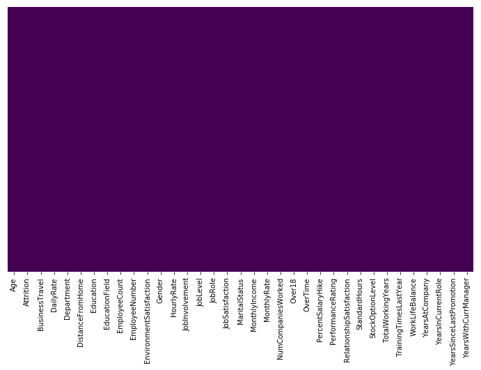

```python
plt.figure(figsize=(12,7))
sns.heatmap(data.isnull(),yticklabels=False,cbar=False,cmap='viridis')
plt.show()
```

In the above Chart we checked for missing values using a heatmap. Thus from the above visualisation we can say that there are no NA in this data.

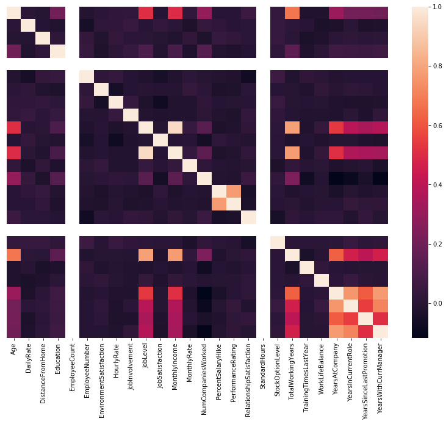

```python
plt.figure(figsize=(14,10))
sns.heatmap(data.corr(),yticklabels=False,cbar=True,linewidths=0)
plt.show()
```

The above data shows there is a huge serial correlation in the data. Dropping these features may cause to lose enough information. We will try using decomposition to solve this problem.

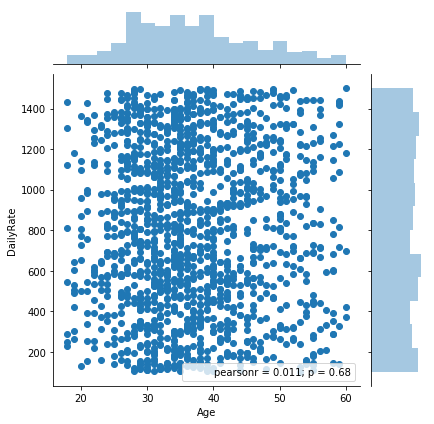

```python
plt.figure(figsize=(8,8))
sns.jointplot(data['Age'],data['DailyRate'])
plt.show()
```

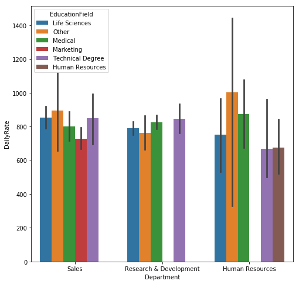

```python
plt.figure(figsize=(8,8))
sns.barplot(x=data['Department'],y=data['DailyRate'],hue=data['EducationField'])
plt.show()
```

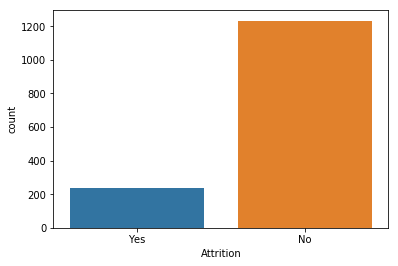

```python
sns.countplot(data['Attrition'])
plt.show()
```

```python
data.columns
```

```
Index(['Age', 'Attrition', 'BusinessTravel', 'DailyRate', 'Department',
       'DistanceFromHome', 'Education', 'EducationField', 'EmployeeCount',
       'EmployeeNumber', 'EnvironmentSatisfaction', 'Gender', 'HourlyRate',
       'JobInvolvement', 'JobLevel', 'JobRole', 'JobSatisfaction',
       'MaritalStatus', 'MonthlyIncome', 'MonthlyRate', 'NumCompaniesWorked',
       'Over18', 'OverTime', 'PercentSalaryHike', 'PerformanceRating',
       'RelationshipSatisfaction', 'StandardHours', 'StockOptionLevel',
       'TotalWorkingYears', 'TrainingTimesLastYear', 'WorkLifeBalance',
       'YearsAtCompany', 'YearsInCurrentRole', 'YearsSinceLastPromotion',
       'YearsWithCurrManager'],
      dtype='object')
```

# Feature Engineering

```python
data.info()
```

```
<class 'pandas.core.frame.DataFrame'>
RangeIndex: 1470 entries, 0 to 1469
Data columns (total 35 columns):
Age                         1470 non-null int64
Attrition                   1470 non-null object
BusinessTravel              1470 non-null object
DailyRate                   1470 non-null int64
Department                  1470 non-null object
DistanceFromHome            1470 non-null int64
Education                   1470 non-null int64
EducationField              1470 non-null object
EmployeeCount               1470 non-null int64
EmployeeNumber              1470 non-null int64
EnvironmentSatisfaction     1470 non-null int64
Gender                      1470 non-null object
HourlyRate                  1470 non-null int64
JobInvolvement              1470 non-null int64
JobLevel                    1470 non-null int64
JobRole                     1470 non-null object
JobSatisfaction             1470 non-null int64
MaritalStatus               1470 non-null object
MonthlyIncome               1470 non-null int64
MonthlyRate                 1470 non-null int64
NumCompaniesWorked          1470 non-null int64
Over18                      1470 non-null object
OverTime                    1470 non-null object
PercentSalaryHike           1470 non-null int64
PerformanceRating           1470 non-null int64
RelationshipSatisfaction    1470 non-null int64
StandardHours               1470 non-null int64
StockOptionLevel            1470 non-null int64
TotalWorkingYears           1470 non-null int64
TrainingTimesLastYear       1470 non-null int64
WorkLifeBalance             1470 non-null int64
YearsAtCompany              1470 non-null int64
YearsInCurrentRole          1470 non-null int64
YearsSinceLastPromotion     1470 non-null int64
YearsWithCurrManager        1470 non-null int64
dtypes: int64(26), object(9)
memory usage: 402.0+ KB
```

**From the above, we can see that there are 9 categorical data. Here we have to create dummy variables of them.**

```python
BusinessTravel = pd.get_dummies(data['BusinessTravel'],drop_first=True)
```

```python
Department = pd.get_dummies(data['Department'],drop_first=True)
```

```python
EducationField = pd.get_dummies(data['EducationField'],drop_first=True)
```

```python
Gender = pd.get_dummies(data['Gender'],drop_first=True)
```

```python
JobRole  = pd.get_dummies(data['JobRole'],drop_first=True)
```

```python
MaritalStatus = pd.get_dummies(data['MaritalStatus'],drop_first=True)
```

```python
Train = data
```

```python
def StrToBin(a):
    if a == 'Yes':
        return 1
    else:
        return 0
```

```python
def StrToBinb(a):
    if a == 'Y':
        return 1
    else:
        return 0
```

```python
Train['Attrition']=Train['Attrition'].apply(StrToBin)
```

```python
Train['OverTime']=Train['OverTime'].apply(StrToBin)
```

```python
Train['Over18']=Train['Over18'].apply(StrToBinb)
```

```python
Train.info()
```

```
<class 'pandas.core.frame.DataFrame'>
RangeIndex: 1470 entries, 0 to 1469
Data columns (total 35 columns):
Age                         1470 non-null int64
Attrition                   1470 non-null int64
BusinessTravel              1470 non-null object
DailyRate                   1470 non-null int64
Department                  1470 non-null object
DistanceFromHome            1470 non-null int64
Education                   1470 non-null int64
EducationField              1470 non-null object
EmployeeCount               1470 non-null int64
EmployeeNumber              1470 non-null int64
EnvironmentSatisfaction     1470 non-null int64
Gender                      1470 non-null object
HourlyRate                  1470 non-null int64
JobInvolvement              1470 non-null int64
JobLevel                    1470 non-null int64
JobRole                     1470 non-null object
JobSatisfaction             1470 non-null int64
MaritalStatus               1470 non-null object
MonthlyIncome               1470 non-null int64
MonthlyRate                 1470 non-null int64
NumCompaniesWorked          1470 non-null int64
Over18                      1470 non-null int64
OverTime                    1470 non-null int64
PercentSalaryHike           1470 non-null int64
PerformanceRating           1470 non-null int64
RelationshipSatisfaction    1470 non-null int64
StandardHours               1470 non-null int64
StockOptionLevel            1470 non-null int64
TotalWorkingYears           1470 non-null int64
TrainingTimesLastYear       1470 non-null int64
WorkLifeBalance             1470 non-null int64
YearsAtCompany              1470 non-null int64
YearsInCurrentRole          1470 non-null int64
YearsSinceLastPromotion     1470 non-null int64
YearsWithCurrManager        1470 non-null int64
dtypes: int64(29), object(6)
memory usage: 402.0+ KB
```

```python
Train.drop(['Department','EducationField','Gender','BusinessTravel','JobRole','MaritalStatus'],axis=1,inplace=True)
```

```python
Train = pd.concat([Train,Department,EducationField,Gender,BusinessTravel,JobRole,MaritalStatus],axis=1)
```

```python
Train.info()
```

```
<class 'pandas.core.frame.DataFrame'>
RangeIndex: 1470 entries, 0 to 1469
Data columns (total 49 columns):
Age                         1470 non-null int64
Attrition                   1470 non-null int64
DailyRate                   1470 non-null int64
DistanceFromHome            1470 non-null int64
Education                   1470 non-null int64
EmployeeCount               1470 non-null int64
EmployeeNumber              1470 non-null int64
EnvironmentSatisfaction     1470 non-null int64
HourlyRate                  1470 non-null int64
JobInvolvement              1470 non-null int64
JobLevel                    1470 non-null int64
JobSatisfaction             1470 non-null int64
MonthlyIncome               1470 non-null int64
MonthlyRate                 1470 non-null int64
NumCompaniesWorked          1470 non-null int64
Over18                      1470 non-null int64
OverTime                    1470 non-null int64
PercentSalaryHike           1470 non-null int64
PerformanceRating           1470 non-null int64
RelationshipSatisfaction    1470 non-null int64
StandardHours               1470 non-null int64
StockOptionLevel            1470 non-null int64
TotalWorkingYears           1470 non-null int64
TrainingTimesLastYear       1470 non-null int64
WorkLifeBalance             1470 non-null int64
YearsAtCompany              1470 non-null int64
YearsInCurrentRole          1470 non-null int64
YearsSinceLastPromotion     1470 non-null int64
YearsWithCurrManager        1470 non-null int64
Research & Development      1470 non-null uint8
Sales                       1470 non-null uint8
Life Sciences               1470 non-null uint8
Marketing                   1470 non-null uint8
Medical                     1470 non-null uint8
Other                       1470 non-null uint8
Technical Degree            1470 non-null uint8
Male                        1470 non-null uint8
Travel_Frequently           1470 non-null uint8
Travel_Rarely               1470 non-null uint8
Human Resources             1470 non-null uint8
Laboratory Technician       1470 non-null uint8
Manager                     1470 non-null uint8
Manufacturing Director      1470 non-null uint8
Research Director           1470 non-null uint8
Research Scientist          1470 non-null uint8
Sales Executive             1470 non-null uint8
Sales Representative        1470 non-null uint8
Married                     1470 non-null uint8
Single                      1470 non-null uint8
dtypes: int64(29), uint8(20)
memory usage: 361.8 KB
```

As we can see, there are many features in this data. Removing the features might lose information. Instead of feature selection, We are going to extract features from this data using Linear Discriminant Analysis.

```python
m = list(Train.columns)
n = list(filter(lambda t: t not in ['Attrition'], m))
```

```python
X = Train[n]
```

```python
y = Train['Attrition']
```

# Train Test Split

```python
from sklearn.model_selection import train_test_split
X_train, X_test, y_train, y_test = train_test_split(X, y, test_size = 0.3, random_state = 0)
```

```python
from sklearn.preprocessing import StandardScaler
sc = StandardScaler()
X_train = sc.fit_transform(X_train)
X_test = sc.transform(X_test)
```

# MODEL 1: Logistic Regression with LDA

# Applying LDA

```python
from sklearn.discriminant_analysis import LinearDiscriminantAnalysis as LDA
```

```python
lda = LDA(n_components = 2)
X_train = lda.fit_transform(X_train, y_train)
X_test = lda.transform(X_test)
```

# Logistic Regression

```python
from sklearn.linear_model import LogisticRegression
classifier = LogisticRegression(penalty='l2', solver='sag', C=1)
fit1 = classifier.fit(X_train, y_train)
```

```python
y_pred = fit1.predict(X_test)
```

# Confusion Matrix and Classification Report

```python
from sklearn.metrics import confusion_matrix,classification_report
cm = confusion_matrix(y_test, y_pred)
cr = classification_report(y_test, y_pred)
```

```python
print(cm)
print(cr)
```

```
[[359  12]
 [ 41  29]]
             precision    recall  f1-score   support

          0       0.90      0.97      0.93       371
          1       0.71      0.41      0.52        70

avg / total       0.87      0.88      0.87       441
```

# MODEL 2: K- Nearest Neighbour

# Train Test Split

```python
from sklearn.model_selection import train_test_split
X_train, X_test, y_train, y_test = train_test_split(X, y, test_size = 0.2, random_state = 0)
```

**Applying LDA**

```python
from sklearn.discriminant_analysis import LinearDiscriminantAnalysis as LDA
```

```python
lda = LDA(n_components = 2,solver='eigen',shrinkage='auto')
X_train = lda.fit_transform(X_train, y_train)
X_test = lda.transform(X_test)
```

**1) Performing KNN**

```python
from sklearn.neighbors import KNeighborsClassifier
knn = KNeighborsClassifier(n_neighbors=17,weights='distance',algorithm='brute')
knn.fit(X_train,y_train)
```

```
KNeighborsClassifier(algorithm='brute', leaf_size=30, metric='minkowski',
           metric_params=None, n_jobs=1, n_neighbors=17, p=2,
           weights='distance')
```

```python
pred = knn.predict(X_test)
```

**Choosing the best K**

```python
error_rate = []
for i in range(1,40):
    knn = KNeighborsClassifier(n_neighbors=i)
    knn.fit(X_train,y_train)
    pred_i = knn.predict(X_test)
    error_rate.append(np.mean(pred_i != y_test))
```

```
Text(0,0.5,'Error Rate')
```

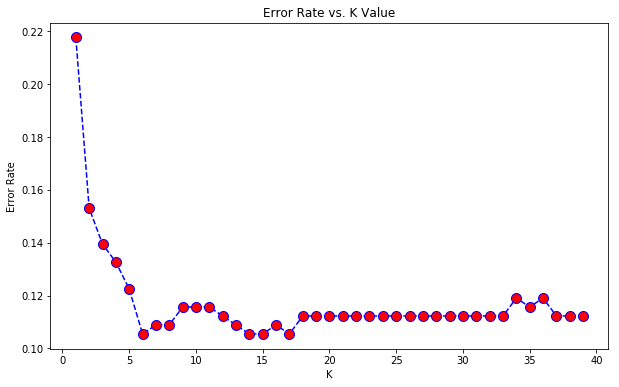

```python
plt.figure(figsize=(10,6))
plt.plot(range(1,40),error_rate,color='blue', linestyle='dashed', marker='o',
         markerfacecolor='red', markersize=10)
plt.title('Error Rate vs. K Value')
plt.xlabel('K')
plt.ylabel('Error Rate')
```

**Report**

```python
from sklearn.metrics import classification_report,confusion_matrix
print(confusion_matrix(y_test,pred))
print(classification_report(y_test,pred))
```

```
[[228  17]
 [ 27  22]]
             precision    recall  f1-score   support

          0       0.89      0.93      0.91       245
          1       0.56      0.45      0.50        49

avg / total       0.84      0.85      0.84       294
```

# MODEL 3: SVM

# Train Test Split

```python
from sklearn.model_selection import train_test_split
X_train, X_test, y_train, y_test = train_test_split(X, y, test_size = 0.3, random_state = 0)
```

**Applying LDA**

```python
from sklearn.discriminant_analysis import LinearDiscriminantAnalysis as LDA
lda = LDA(n_components = 2,solver='svd')
X_train = lda.fit_transform(X_train, y_train)
X_test = lda.transform(X_test)
```

```python
from sklearn.svm import SVC
model = SVC(C=100,kernel = 'rbf')
model.fit(X_train,y_train)
```

```
SVC(C=100, cache_size=200, class_weight=None, coef0=0.0,
  decision_function_shape='ovr', degree=3, gamma='auto', kernel='rbf',
  max_iter=-1, probability=False, random_state=None, shrinking=True,
  tol=0.001, verbose=False)
```

```python
predictions = model.predict(X_test)
```

**Report**

```python
from sklearn.metrics import classification_report,confusion_matrix
print(confusion_matrix(y_test,predictions))
print(classification_report(y_test,predictions))
```

```
[[359  12]
 [ 41  29]]
             precision    recall  f1-score   support

          0       0.90      0.97      0.93       371
          1       0.71      0.41      0.52        70

avg / total       0.87      0.88      0.87       441
```

# Decision Tree

```python
from sklearn.tree import DecisionTreeClassifier as DTC
```

```python
dt = DTC(criterion='entropy',splitter='random')
```

```python
tree = dt.fit(X_train,y_train)
```

```python
pred_t = dt.predict(X_test)
```

```python
cm = confusion_matrix(y_test,pred_t)
```

```python
cr = classification_report(y_test,pred_t)
```

```python
print(cm)
print(cr)
```

```
[[337  34]
 [ 41  29]]
             precision    recall  f1-score   support

          0       0.89      0.91      0.90       371
          1       0.46      0.41      0.44        70

avg / total       0.82      0.83      0.83       441
```

# K-FOLD CROSS VALIDATION

**Logistic Regression**

```python
from sklearn.model_selection import cross_val_score
accuracies = cross_val_score(estimator = fit1, X = X_train, y = y_train, cv = 10)
print('mean: ' ,accuracies.mean())
print('SD:' ,accuracies.std())
print(accuracies)
```

```
mean:  0.885384542166
SD: 0.0179605849583
[ 0.875       0.875       0.89320388  0.85436893  0.86407767  0.91262136
  0.88349515  0.89215686  0.91176471  0.89215686]
```

**KNN**

```python
from sklearn.model_selection import cross_val_score
accuracies = cross_val_score(estimator = knn, X = X_train, y = y_train, cv = 10)
print('mean: ' ,accuracies.mean())
print('SD:' ,accuracies.std())
print(accuracies)
```

```
mean:  0.888306681896
SD: 0.0210063164393
[ 0.85576923  0.89423077  0.88349515  0.87378641  0.85436893  0.9223301
  0.89320388  0.89215686  0.91176471  0.90196078]
```

**SVM**

```python
from sklearn.model_selection import cross_val_score
accuracies = cross_val_score(estimator = model, X = X_train, y = y_train, cv = 10)
print('mean: ' ,accuracies.mean())
print('SD:' ,accuracies.std())
print(accuracies)
```

```
mean:  0.882452884066
SD: 0.0178607117406
[ 0.875       0.875       0.89320388  0.85436893  0.85436893  0.91262136
  0.88349515  0.88235294  0.90196078  0.89215686]
```

**Decision Tree**

```python
from sklearn.model_selection import cross_val_score
accuracies = cross_val_score(estimator = tree, X = X_train, y = y_train, cv = 10)
print('mean: ' ,accuracies.mean())
print('SD:' ,accuracies.std())
print(accuracies)
```

```
mean:  0.821209308966
SD: 0.0407573073695
[ 0.76923077  0.85576923  0.77669903  0.83495146  0.83495146  0.80582524
  0.86407767  0.88235294  0.83333333  0.75490196]
```

From this we can see that the best algorithm to predict if an employee will leave or not is **KNN** followed by **Logistic Regression**.